# MI Wave 1 analyses: JNeuro reanalysis/replication

# 1 intro

```r
## libraries ----

library(here)
library(data.table)
source(here("src", "stroop-rsa-pc.R"))
library(knitr)
library(dplyr)
library(tidyr)
library(ggplot2)
library(mfutils)
library(ggseg)
library(ggsegExtra)
library(ggsegSchaefer)
library(ggsegGlasser)

## settings, params ----

opts_chunk$set(echo = TRUE, out.width = "100%")
theme_set(theme_bw(base_size = 10))

if (exists("params")) {
  ttype_subset <- params$ttype_subset
  prewh <- params$prewh
  measure <- params$measure
  roiset <- params$roiset
} else {
  ttype_subset <- "bias"
  prewh <- "obsall"
  measure <- "cveuc"
  roiset <- "glasser2016_parcel"
}

theme_surface <- list(
  theme(
    axis.text = element_blank(), panel.grid = element_blank(), panel.border = element_blank(),
    axis.ticks = element_blank(), legend.position = c(0.5, 0.5), legend.title = element_text(size = 5),
    legend.background = element_blank(), legend.text = element_text(size = 5), legend.direction = "horizontal",
    legend.key.height = unit(1/5, "cm"), legend.key.width = unit(1/4, "cm")
  )
)


## constants ----

wd <- here()
subjlists <- "mi1"
seswaves <- c("proactive_wave1")
glmname <- "lsall_1rpm"
sessions <- c("proactive")
statistics <- c("m", "t_stat")
titles <- c("mean coefficient", "t statistic")


## data ----

## read regression weights:

dat <- Map(
  function(subjlist, suffix) {
    fname <- construct_filename_weights(
        measure = measure, subjlist = subjlist, glmname = glmname,
        ttype_subset = ttype_subset, roiset = roiset, prewh = prewh, suffix = suffix
        )
    fread(fname)
  },
  subjlist = subjlists,
  suffix = paste0("__seswave-", seswaves)
)
dat <- rbindlist(dat)


## get ggseg atlas and format data to match:

dat <- dat %>% rename(region = roi)

if (roiset == "schaefer2018_17_200_parcel") {

  atlas <- schaefer17_200
  k <- schaefer2018_17_200_fsaverage5$key %>% select(region = parcel, network)

  rois <- data.frame(
    region = c(
    "17Networks_LH_ContA_PFClv_1",
    "17Networks_LH_ContA_PFCl_1",
    "17Networks_LH_ContA_PFCl_2",
    "17Networks_LH_ContA_PFCl_3",
    "17Networks_RH_ContA_PFCl_1",
    "17Networks_RH_ContA_PFCl_2",
    "17Networks_LH_SalVentAttnB_PFCmp_1",
    "17Networks_RH_SalVentAttnB_PFCmp_1",
    "17Networks_LH_SalVentAttnA_FrMed_1",
    "17Networks_RH_SalVentAttnA_FrMed_1"
    ),
    location = c(rep("lateral", 6), rep("medial", 4))
  )

} else if (roiset == "glasser2016_parcel") {

  atlas <- glasser
  k <- glasser2016_fsaverage5$key %>% select(region = parcel, network)

  dat <- dat %>% filter(!region %in% "L_10pp")  ## not in glasser ggseg atlas?
  ## create region column in ggseg atlas that matches data:
  hemi <- ifelse(atlas$data$hemi == "left", "L_", "R_")
  atlas$data$region <- ifelse(is.na(atlas$data$region), NA, paste0(hemi, atlas$data$region))

  rois <- data.frame(
    region = combo_paste(c("L_", "R_"), c("SCEF", "8BM",  "p32pr", "a32pr", "p9-46v", "i6-8", "8Av", "8C")),
    location = c(rep("medial", 8), rep("lateral", 8))
  )

}

## add network information:
atlas$data <- left_join(atlas$data, k, by = "region")
dat <- left_join(dat, k, by = "region")


## calculate ----

## add subject set information:
subjlists <- rbind(
  data.table(subjlist = "jneurosci", subject = fread(here("out", "subjlist_jneurosci_primary.txt"))[[1]]),
  data.table(subjlist = "replication", subject =
               fread(here("out", "subjlist_jneurosci_replication_primary.txt"))[[1]])
)
dat_subjs <- dat %>% inner_join(subjlists, by = "subject")
dat_subjs <- bind_rows(dat_subjs, dat_subjs %>% mutate(subjlist = "jneurosci \u222A replication"))

dat_sum <- dat_subjs %>%
  group_by(subjlist, session, term, wave, region) %>%
  summarize(
    m = mean(b),
    t_stat = t.test(b)$statistic,
    p = t.test(b, alternative = "greater")$p.value,
    .groups = "drop_last"
    ) %>%
  mutate(p_fdr = p.adjust(p, "fdr"))

dat_sum <- dat_sum %>% filter(term %in% models[[measure]])

n_subjs <- table(unique(dat_subjs[, c("subject", "subjlist")])$subjlist)
```

This file displays group-level RSA model coefficients (means, test statistics).

**Analysis parameters**:

- Item type: bias
- Prewhitening type: obsallave
- Similarity measure: crcor
- ROI set: glasser2016_parcel

**Subject samples**:

Analyses are conducted with three different sets of subjects.

- the **jneurosci** set: N = 46, unrelated
  - The paper had N=49; 3 subjects are not included in these analyses: 873968, DMCC1971064, DMCC9478705
  - the latter subject is not included due to failed fmriprep preprocessing
  - the former two subjects were unintentionally excluded due to meeting jo’s criteria for “bad runs”: >20% of TRs excluded due to high motion (I am running these subjects now)
- the **replication** set: N = 21, unrelated (to each other and to those in jneurosci)
- the **jneurosci** $\bigcup$ **replication** set: N = 67, unrelated

# 2 Brains

## 2.1 Unthresholded

### 2.1.1 Common scale

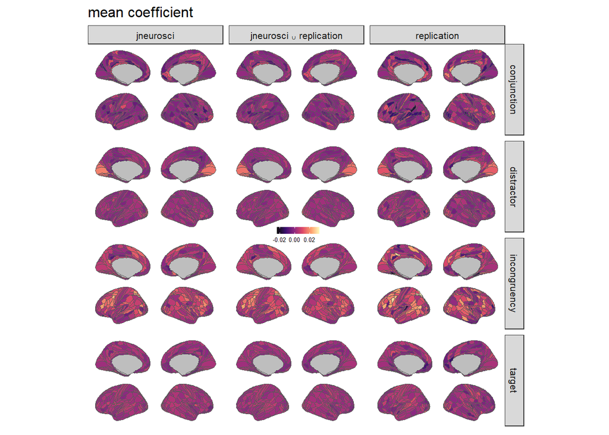

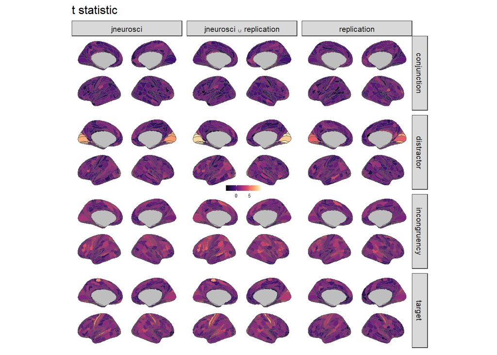

```r
for (stat_i in seq_along(statistics)) {

  p <- dat_sum %>%
    ggplot() +
    geom_brain(
      aes_string(fill = statistics[stat_i]),
      atlas = atlas, position = position_brain(side ~ hemi)
      ) +
    scale_fill_viridis_c(
      option = "magma", na.value = "grey",
      breaks = scales::extended_breaks(4)
      ) +
    facet_grid(rows = vars(term), cols = vars(subjlist)) +
    theme_surface +
    labs(title = titles[stat_i], fill = NULL)

  print(p)

}
```

### 2.1.2 Separate scales by model

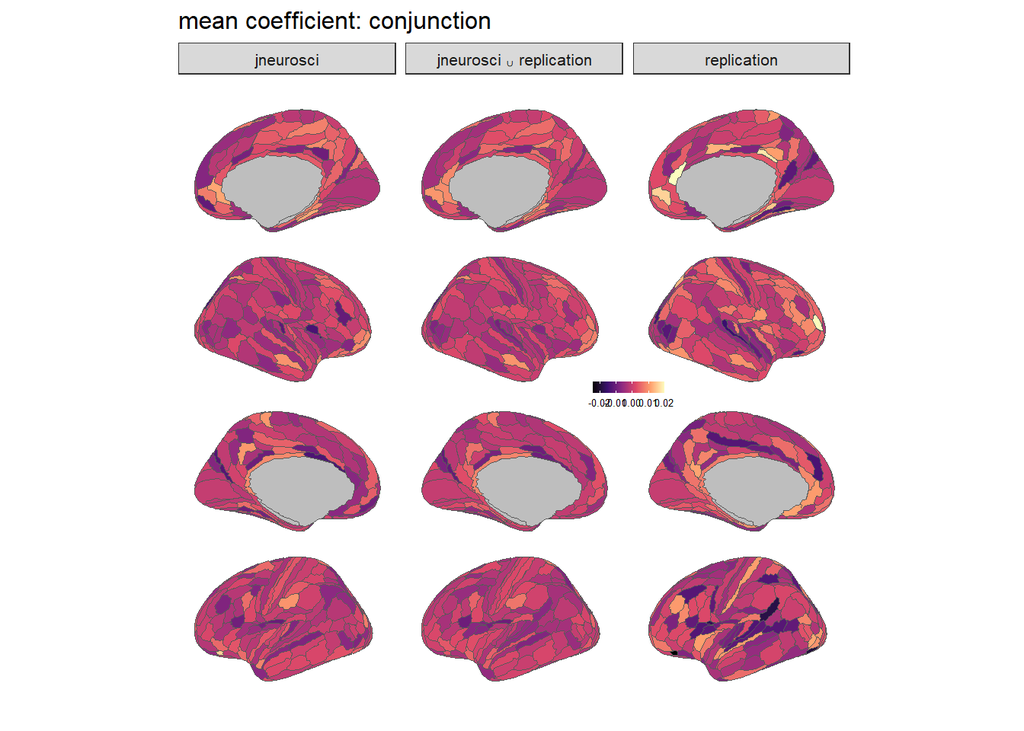

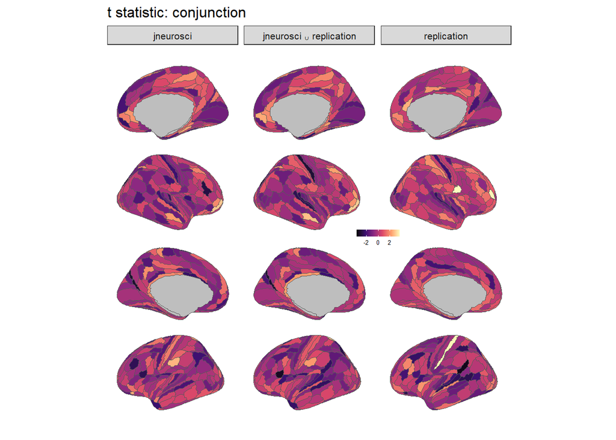

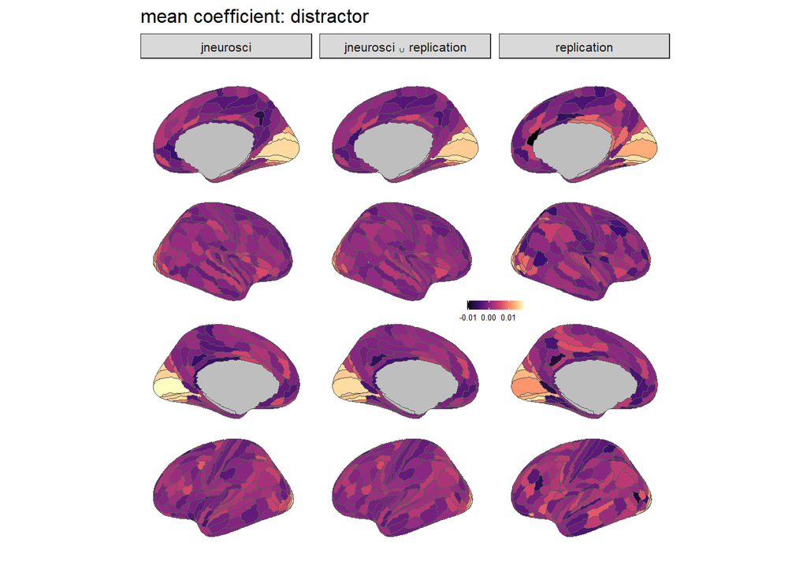

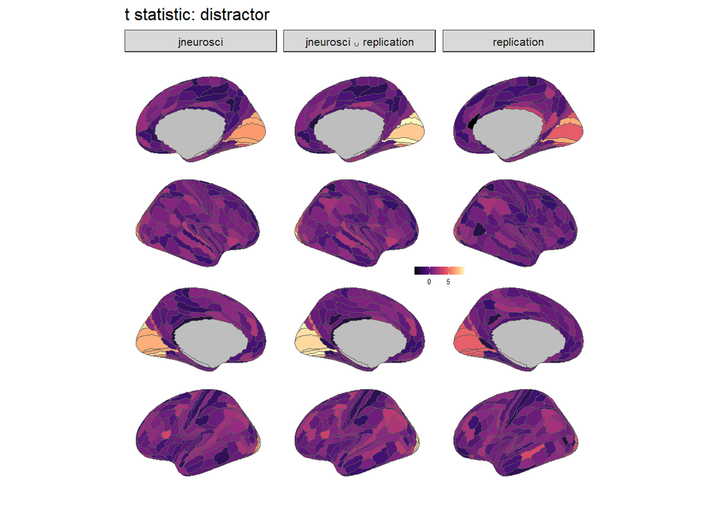

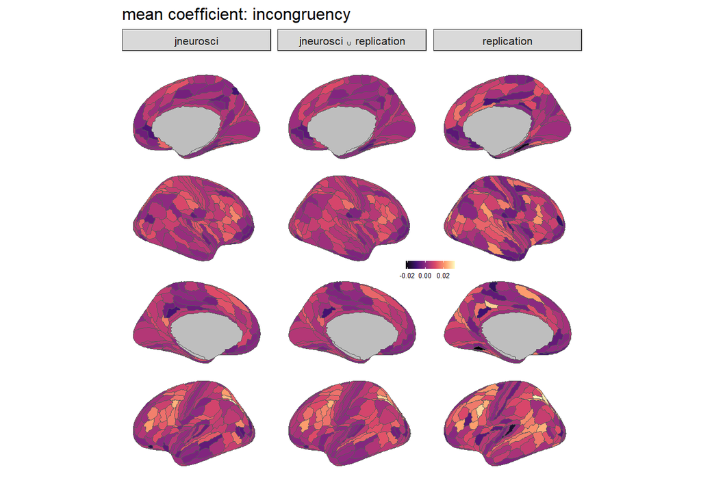

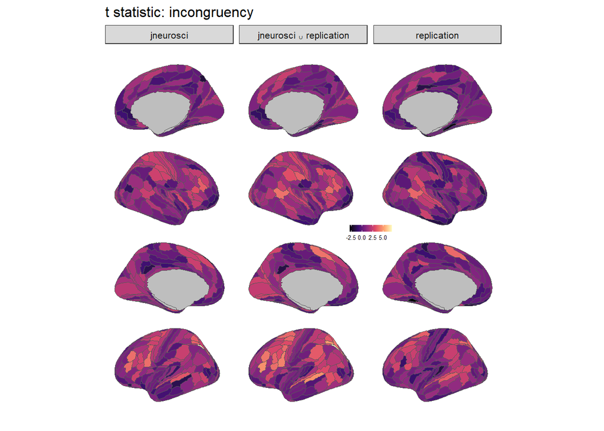

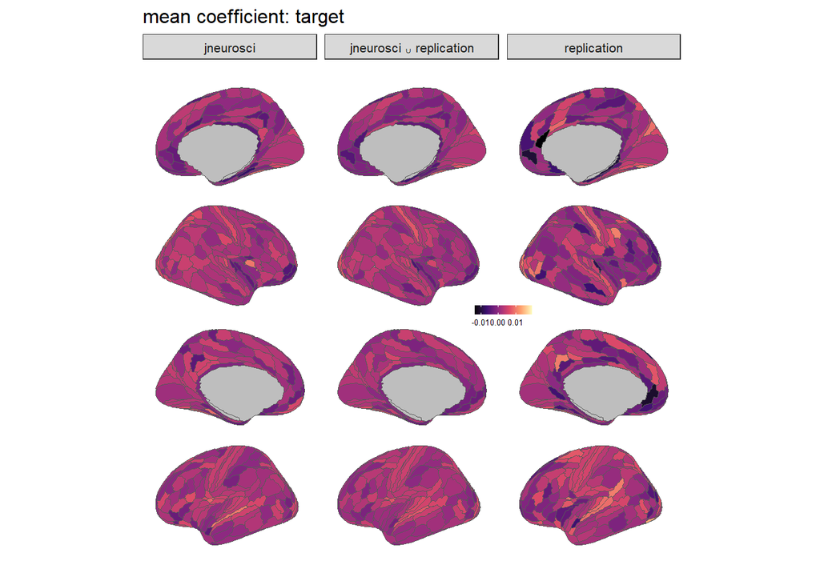

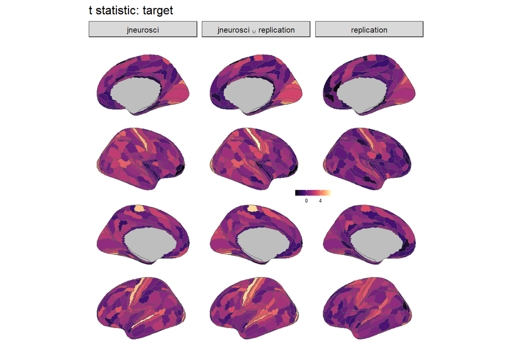

```r
for (model_i in seq_along(models[[measure]])) {

  model <- models[[measure]][model_i]

  for (stat_i in seq_along(statistics)) {

    p <- dat_sum %>%
      filter(term %in% model) %>%
      ggplot() +
      geom_brain(
        aes_string(fill = statistics[stat_i]),
        atlas = atlas, position = position_brain(hemi + side ~ .)
        ) +
      scale_fill_viridis_c(
        option = "magma", na.value = "grey",
        breaks = scales::extended_breaks(4)
        ) +
      facet_grid(cols = vars(subjlist)) +
      theme_surface +
      theme(legend.position = c(2/3, 0.5)) +
      labs(title = paste0(titles[stat_i], ": ", model), fill = NULL)

    print(p)

  }

}
```

## 2.2 Thresholded

Three consecutive thresholds are used, each more liberal than the previous:

- **p_FDR < 0.05**: parcels with mean model fit significantly greater than 0 following FDR correction over all parcels (separately per model)
- **p_uncorr < 0.05**: parcels with mean model fit significantly greater than 0 (uncorrected)
- **t_stat > 0**: parcels with mean model fit numerically greater than zero

### 2.2.1 Common scale

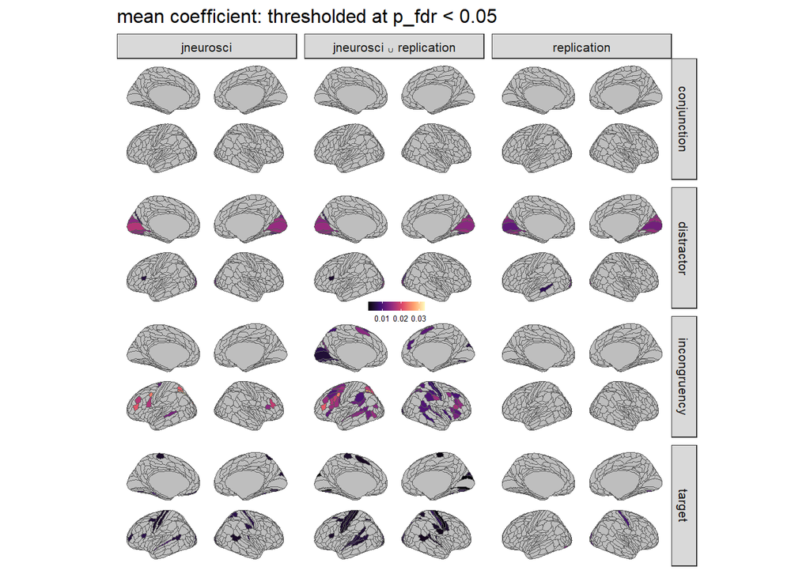

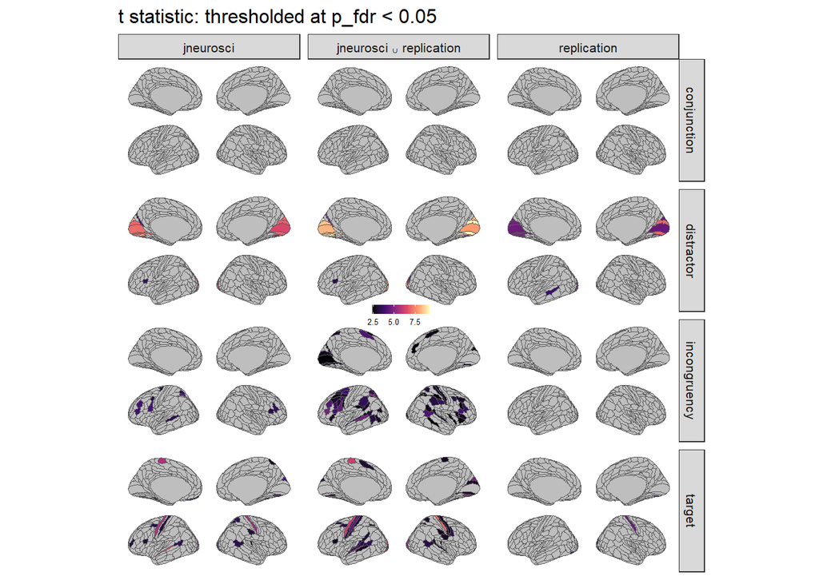

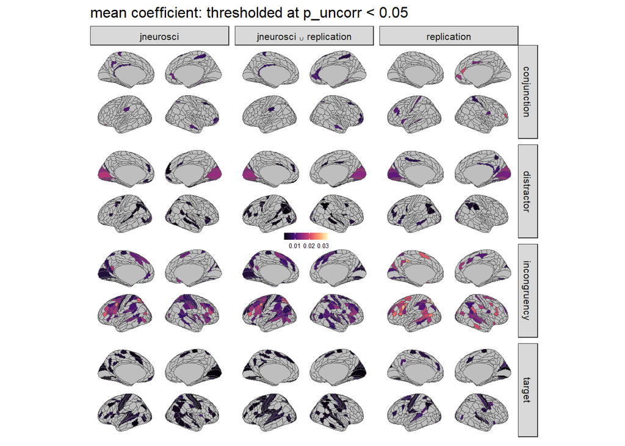

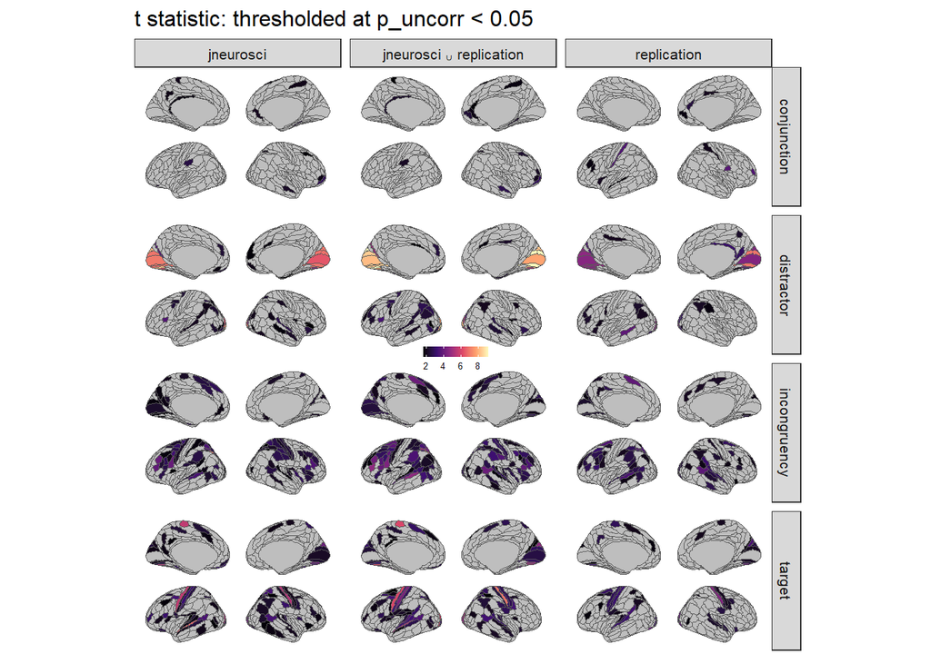

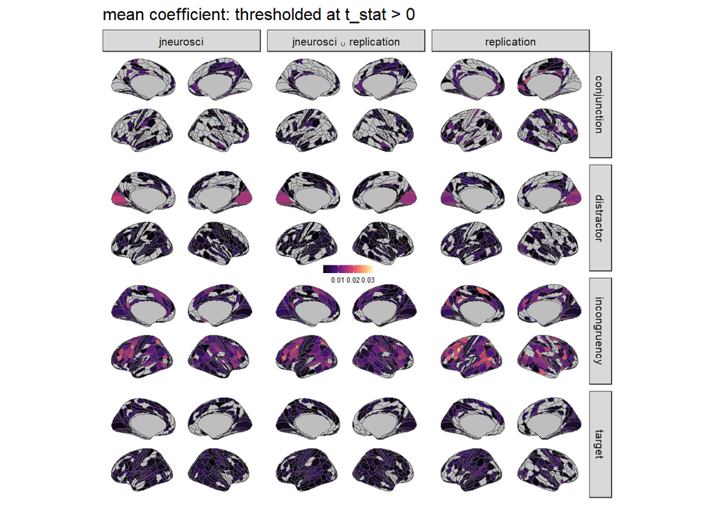

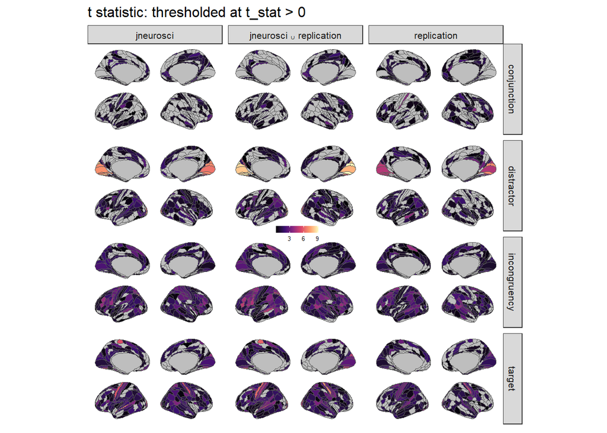

```r
dat_sum$is_in_thresh_fdr <- dat_sum$p_fdr < 0.05
dat_sum$is_in_thresh_p <- dat_sum$p < 0.05
dat_sum$is_in_thresh_sign <- dat_sum$t_stat > 0

thresholds <- c("p_fdr < 0.05", "p_uncorr < 0.05", "t_stat > 0")
thresholds_nms <- c("is_in_thresh_fdr", "is_in_thresh_p", "is_in_thresh_sign")

for (thresh_i in seq_along(thresholds)) {

  threshold_nm <- thresholds_nms[thresh_i]

  for (stat_i in seq_along(statistics)) {

    dat_sum$thresh <- as.numeric(ifelse(dat_sum[[threshold_nm]], dat_sum[[statistics[stat_i]]], NA))

    p <- dat_sum %>%
      ggplot() +
      geom_brain(
        aes(fill = thresh),
        atlas = atlas, position = position_brain(side ~ hemi)
        ) +
      scale_fill_viridis_c(
        option = "magma", na.value = "grey",
        breaks = scales::extended_breaks(4)
        ) +
      facet_grid(rows = vars(term), cols = vars(subjlist)) +
      theme_surface +
      labs(title = paste0(titles[stat_i], ": thresholded at ", thresholds[thresh_i]), fill = NULL)

    print(p)

  }

}
```

# 3 Tables

## 3.1 Do identified parcels replicate?

Parcels within the **jneurosci** sample that survived FDR correction (whole-cortex) are identified. Are these parcels still significant (uncorrected) in the **replication** sample?

Displayed are stats within the replication sample for “successfully replicated” parcels (p<0.05).

```r
sig_orig <- dat_sum %>% filter(p_fdr < 0.05, subjlist == "jneurosci") %>% ungroup %>% select(term, region)

d <- enlist(c("target", "distractor", "incongruency"))
for (model in names(d)) {

  d[[model]] <- dat_sum %>%
    ungroup %>%
    filter(
      subjlist == "replication", term == model, region %in% sig_orig$region[sig_orig$term == model], p < 0.05
    ) %>%
    select(region, m, t_stat, p) %>%
    arrange(region)

}

lapply(d, kable)
```

$target

| region | m | t_stat | p |
| --- | --- | --- | --- |
| L_3b | 0.0053551 | 3.137489 | 0.0025921 |
| L_4 | 0.0046792 | 2.857352 | 0.0048683 |
| L_V4 | 0.0064261 | 3.043159 | 0.0032099 |
| L_VVC | 0.0078534 | 2.702483 | 0.0068517 |
| R_3b | 0.0091339 | 4.476238 | 0.0001156 |
| R_V3 | 0.0059128 | 2.543924 | 0.0096636 |
| R_V3B | 0.0091059 | 2.408760 | 0.0128845 |
| R_V4 | 0.0099106 | 3.871921 | 0.0004745 |
| R_V8 | 0.0194057 | 5.751258 | 0.0000063 |

$distractor

| region | m | t_stat | p |
| --- | --- | --- | --- |
| L_DVT | 0.0081490 | 3.448625 | 0.0012698 |
| L_V1 | 0.0110440 | 4.570190 | 0.0000929 |
| L_V2 | 0.0131808 | 4.701856 | 0.0000684 |
| L_V3 | 0.0161448 | 4.514947 | 0.0001056 |
| L_V4 | 0.0108814 | 4.601926 | 0.0000863 |
| R_V1 | 0.0125700 | 4.477750 | 0.0001152 |
| R_V2 | 0.0155967 | 6.892245 | 0.0000005 |
| R_V3 | 0.0146107 | 4.412499 | 0.0001341 |
| R_V4 | 0.0086968 | 3.064073 | 0.0030617 |

$incongruency

| region | m | t_stat | p |
| --- | --- | --- | --- |
| L_6r | 0.0132564 | 1.990996 | 0.0301599 |
| L_IFSa | 0.0226089 | 2.772169 | 0.0058790 |
| L_IP0 | 0.0240687 | 2.602486 | 0.0085175 |
| L_IP1 | 0.0184843 | 2.649686 | 0.0076884 |
| L_LIPd | 0.0314012 | 3.734527 | 0.0006538 |
| L_PEF | 0.0236410 | 1.965914 | 0.0316727 |
| L_STSdp | 0.0183599 | 3.470335 | 0.0012077 |
| R_44 | 0.0204173 | 2.233679 | 0.0185430 |

## 3.2 FDR significant parcels in the full dataset

Displayed are parcels that are significant after FDR correction (whole-cortex) in the higher-powered jneurosci+replication sample.

```r
sig_all <- dat_sum %>%
  filter(p_fdr < 0.05, !subjlist %in% c("jneurosci", "replication")) %>%
  ungroup %>%
  select(term, region)

d <- enlist(c("target", "distractor", "incongruency"))
for (model in names(d)) {

  d[[model]] <- dat_sum %>%
    ungroup %>%
    filter(
      !subjlist %in% c("jneurosci", "replication"),
      term == model,
      region %in% sig_all$region[sig_all$term == model],
      p_fdr < 0.05
    ) %>%
    select(region, m, t_stat, p) %>%
    arrange(region)

}

lapply(d, kable)
```

$target

| region | m | t_stat | p |
| --- | --- | --- | --- |
| L_1 | 0.0034113 | 2.904206 | 0.0025019 |
| L_13l | 0.0041799 | 2.841491 | 0.0029836 |
| L_3a | 0.0035706 | 3.164785 | 0.0011740 |
| L_3b | 0.0047068 | 4.325161 | 0.0000264 |
| L_4 | 0.0045109 | 6.104682 | 0.0000000 |
| L_44 | 0.0044623 | 2.755967 | 0.0037788 |
| L_55b | 0.0045826 | 3.292845 | 0.0007980 |
| L_A4 | 0.0052911 | 3.225572 | 0.0009785 |
| L_A5 | 0.0070746 | 5.086280 | 0.0000016 |
| L_FFC | 0.0042087 | 2.647074 | 0.0050715 |
| L_i6-8 | 0.0051655 | 2.949959 | 0.0021969 |
| L_LIPd | 0.0048183 | 3.149616 | 0.0012282 |
| L_PBelt | 0.0060358 | 3.528187 | 0.0003836 |
| L_PSL | 0.0049484 | 3.037501 | 0.0017073 |
| L_SCEF | 0.0039442 | 2.990906 | 0.0019536 |
| L_STSdp | 0.0046412 | 2.704372 | 0.0043481 |
| L_TF | 0.0037870 | 3.037290 | 0.0017084 |
| L_TPOJ1 | 0.0056188 | 3.500177 | 0.0004192 |
| L_V3 | 0.0024372 | 3.060450 | 0.0015970 |
| L_V4 | 0.0060778 | 6.013489 | 0.0000000 |
| L_V8 | 0.0084321 | 3.282395 | 0.0008238 |
| L_VVC | 0.0069472 | 3.876136 | 0.0001234 |
| R_3a | 0.0030413 | 3.086522 | 0.0014796 |
| R_3b | 0.0071888 | 6.910296 | 0.0000000 |
| R_4 | 0.0028273 | 2.756938 | 0.0037687 |
| R_6v | 0.0046306 | 3.299159 | 0.0007828 |
| R_7PC | 0.0044860 | 2.928363 | 0.0023363 |
| R_A1 | 0.0053922 | 2.652287 | 0.0050014 |
| R_A4 | 0.0043065 | 3.031289 | 0.0017384 |
| R_IPS1 | 0.0080934 | 3.348632 | 0.0006726 |
| R_LIPd | 0.0052223 | 3.103234 | 0.0014087 |
| R_OP4 | 0.0033168 | 2.807136 | 0.0032824 |
| R_PFop | 0.0043143 | 2.775537 | 0.0035813 |
| R_TPOJ1 | 0.0036999 | 3.263104 | 0.0008736 |
| R_V2 | 0.0025964 | 2.912064 | 0.0024468 |
| R_V3 | 0.0053155 | 4.733343 | 0.0000060 |
| R_V3B | 0.0085271 | 3.788258 | 0.0001653 |
| R_V4 | 0.0073340 | 5.063134 | 0.0000018 |
| R_V7 | 0.0061943 | 2.670003 | 0.0047698 |
| R_V8 | 0.0126556 | 5.369353 | 0.0000005 |
| R_VVC | 0.0077042 | 3.654165 | 0.0002562 |

$distractor

| region | m | t_stat | p |
| --- | --- | --- | --- |
| L_44 | 0.0046049 | 3.355967 | 0.0006576 |
| L_DVT | 0.0071194 | 4.860776 | 0.0000038 |
| L_V1 | 0.0153788 | 8.148909 | 0.0000000 |
| L_V2 | 0.0142011 | 8.387950 | 0.0000000 |
| L_V3 | 0.0156360 | 9.204677 | 0.0000000 |
| L_V4 | 0.0105434 | 7.749669 | 0.0000000 |
| L_V8 | 0.0094782 | 3.854775 | 0.0001325 |
| R_V1 | 0.0144328 | 7.770443 | 0.0000000 |
| R_V2 | 0.0157106 | 9.137508 | 0.0000000 |
| R_V3 | 0.0131637 | 8.189019 | 0.0000000 |
| R_V3CD | 0.0080469 | 3.426399 | 0.0005285 |
| R_V4 | 0.0083617 | 5.379908 | 0.0000005 |

$incongruency

| region | m | t_stat | p |
| --- | --- | --- | --- |
| L_44 | 0.0157123 | 3.920670 | 0.0001063 |
| L_55b | 0.0143101 | 3.117338 | 0.0013514 |
| L_6a | 0.0129055 | 3.734213 | 0.0001974 |
| L_6ma | 0.0104852 | 2.612096 | 0.0055653 |
| L_6r | 0.0159012 | 4.396646 | 0.0000205 |
| L_6v | 0.0125828 | 2.452669 | 0.0084155 |
| L_7Am | 0.0090756 | 2.843233 | 0.0029691 |
| L_8Av | 0.0096346 | 2.497351 | 0.0075071 |
| L_8C | 0.0112916 | 2.896589 | 0.0025563 |
| L_A5 | 0.0136241 | 3.547086 | 0.0003613 |
| L_DVT | 0.0126405 | 2.863206 | 0.0028079 |
| L_FEF | 0.0161706 | 3.773417 | 0.0001735 |
| L_FOP5 | 0.0111824 | 2.822150 | 0.0031486 |
| L_FST | 0.0154050 | 2.890740 | 0.0025988 |
| L_i6-8 | 0.0141126 | 2.659429 | 0.0049068 |
| L_IFJa | 0.0171952 | 3.622747 | 0.0002835 |
| L_IFJp | 0.0185458 | 3.068593 | 0.0015594 |
| L_IFSa | 0.0218769 | 4.740881 | 0.0000059 |
| L_IP0 | 0.0237591 | 4.637571 | 0.0000086 |
| L_IP1 | 0.0284428 | 7.132484 | 0.0000000 |
| L_IP2 | 0.0133378 | 3.295013 | 0.0007928 |
| L_LIPd | 0.0269562 | 4.987529 | 0.0000024 |
| L_LIPv | 0.0181145 | 3.426095 | 0.0005290 |
| L_MIP | 0.0193469 | 4.100916 | 0.0000576 |
| L_p9-46v | 0.0156083 | 4.144002 | 0.0000496 |
| L_PEF | 0.0240215 | 3.828637 | 0.0001446 |
| L_PF | 0.0097846 | 3.470959 | 0.0004596 |
| L_PFcm | 0.0120420 | 2.544351 | 0.0066478 |
| L_PHT | 0.0123277 | 3.257357 | 0.0008889 |
| L_PSL | 0.0118353 | 2.913703 | 0.0024355 |
| L_SCEF | 0.0145182 | 4.066184 | 0.0000649 |
| L_SFL | 0.0104302 | 2.755891 | 0.0037796 |
| L_STSdp | 0.0146779 | 4.719432 | 0.0000064 |
| L_TPOJ1 | 0.0119087 | 3.077975 | 0.0015172 |
| L_TPOJ3 | 0.0143534 | 2.617068 | 0.0054926 |
| L_V1 | 0.0052908 | 2.449369 | 0.0084864 |
| L_V2 | 0.0066991 | 2.708620 | 0.0042984 |
| L_VIP | 0.0145630 | 3.081431 | 0.0015019 |
| R_1 | 0.0086577 | 2.989690 | 0.0019605 |
| R_3b | 0.0071092 | 2.739041 | 0.0039575 |
| R_44 | 0.0163973 | 3.867696 | 0.0001270 |
| R_6ma | 0.0098592 | 2.969952 | 0.0020748 |
| R_7PC | 0.0101326 | 3.056849 | 0.0016138 |
| R_8C | 0.0093482 | 2.930295 | 0.0023235 |
| R_A4 | 0.0100760 | 2.866749 | 0.0027801 |
| R_AVI | 0.0128629 | 2.584205 | 0.0059900 |
| R_d32 | 0.0099120 | 2.471785 | 0.0080155 |
| R_FFC | 0.0093740 | 2.721306 | 0.0041531 |
| R_FOP4 | 0.0124139 | 2.813151 | 0.0032282 |
| R_FOP5 | 0.0105540 | 2.732315 | 0.0040307 |
| R_IFJa | 0.0126388 | 2.441195 | 0.0086642 |
| R_IFSp | 0.0149057 | 3.472910 | 0.0004568 |
| R_IP1 | 0.0102512 | 2.586159 | 0.0059593 |
| R_IP2 | 0.0110241 | 2.504938 | 0.0073620 |
| R_IPS1 | 0.0152395 | 2.964146 | 0.0021096 |
| R_LIPd | 0.0131453 | 2.592377 | 0.0058626 |
| R_PEF | 0.0146689 | 3.262634 | 0.0008748 |
| R_PF | 0.0099840 | 3.205560 | 0.0010392 |
| R_PFop | 0.0157828 | 3.565820 | 0.0003403 |
| R_PFt | 0.0094399 | 2.421828 | 0.0090989 |
| R_PoI2 | 0.0089208 | 2.598349 | 0.0057711 |
| R_SCEF | 0.0107658 | 2.570013 | 0.0062172 |
| R_STSvp | 0.0088712 | 2.441139 | 0.0086654 |
| R_STV | 0.0100257 | 2.674123 | 0.0047173 |
| R_TPOJ1 | 0.0101508 | 4.016607 | 0.0000768 |
| R_V3 | 0.0061545 | 2.746618 | 0.0038766 |

## 3.3 ROI-based analysis

Which ROIs (parcels) survive FDR correction over the reduced set of 16 ROIs? This is tested separately for each subject set (jneuro, replication, jneuro+replication).

```r
dat_sum_rois <- dat_sum %>% filter(region %in% rois$region) %>% mutate(p_fdr = p.adjust(p, "fdr"))

d <- enlist(c("target", "distractor", "incongruency"))
for (model in names(d)) {

  d[[model]] <- dat_sum_rois %>%
    ungroup %>%
    filter(term == model, p_fdr < 0.05) %>%
    select(region, subjlist, m, t_stat, p, p_fdr) %>%
    arrange(region, subjlist)
}

lapply(d, kable)
```

$target

| region | subjlist | m | t_stat | p | p_fdr |
| --- | --- | --- | --- | --- | --- |
| L_i6-8 | jneurosci ∪ replication | 0.0051655 | 2.949959 | 0.0021969 | 0.0175756 |
| L_SCEF | jneurosci ∪ replication | 0.0039442 | 2.990906 | 0.0019536 | 0.0175756 |
| R_SCEF | jneurosci ∪ replication | 0.0044229 | 2.430928 | 0.0088922 | 0.0474253 |

$distractor

| region | subjlist | m | t_stat | p | p_fdr |
| --- | --- | --- | --- | --- | --- |

$incongruency

| region | subjlist | m | t_stat | p | p_fdr |
| --- | --- | --- | --- | --- | --- |
| L_8Av | jneurosci ∪ replication | 0.0096346 | 2.497351 | 0.0075071 | 0.0171592 |
| L_8Av | replication | 0.0200746 | 3.142122 | 0.0025650 | 0.0205198 |
| L_8BM | jneurosci | 0.0139027 | 2.839558 | 0.0033793 | 0.0245854 |
| L_8BM | jneurosci ∪ replication | 0.0098305 | 2.283516 | 0.0128131 | 0.0233151 |
| L_8C | jneurosci ∪ replication | 0.0112916 | 2.896589 | 0.0025563 | 0.0102250 |
| L_8C | replication | 0.0171250 | 2.740807 | 0.0062992 | 0.0335959 |
| L_i6-8 | jneurosci | 0.0158089 | 2.246068 | 0.0148275 | 0.0338913 |
| L_i6-8 | jneurosci ∪ replication | 0.0141126 | 2.659429 | 0.0049068 | 0.0157019 |
| L_p32pr | jneurosci | 0.0122515 | 2.616797 | 0.0060216 | 0.0245854 |
| L_p32pr | jneurosci ∪ replication | 0.0084734 | 2.075619 | 0.0209147 | 0.0304214 |
| L_p9-46v | jneurosci | 0.0179087 | 3.947493 | 0.0001373 | 0.0021965 |
| L_p9-46v | jneurosci ∪ replication | 0.0156083 | 4.144002 | 0.0000496 | 0.0005190 |
| L_SCEF | jneurosci | 0.0112525 | 2.519651 | 0.0076829 | 0.0245854 |
| L_SCEF | jneurosci ∪ replication | 0.0145182 | 4.066184 | 0.0000649 | 0.0005190 |
| L_SCEF | replication | 0.0216716 | 3.819243 | 0.0005366 | 0.0085858 |
| R_8BM | jneurosci ∪ replication | 0.0073005 | 1.906445 | 0.0304738 | 0.0406318 |
| R_8C | jneurosci | 0.0094610 | 2.441429 | 0.0093127 | 0.0248340 |
| R_8C | jneurosci ∪ replication | 0.0093482 | 2.930295 | 0.0023235 | 0.0102250 |
| R_p32pr | jneurosci ∪ replication | 0.0079071 | 2.269698 | 0.0132495 | 0.0233151 |
| R_p9-46v | jneurosci | 0.0115754 | 2.536925 | 0.0073600 | 0.0245854 |
| R_p9-46v | jneurosci ∪ replication | 0.0084683 | 2.230145 | 0.0145719 | 0.0233151 |
| R_SCEF | jneurosci | 0.0119603 | 2.143818 | 0.0187435 | 0.0374870 |
| R_SCEF | jneurosci ∪ replication | 0.0107658 | 2.570013 | 0.0062172 | 0.0165791 |

# 4 Bar plots

```r
## prep for plotting:

dat_subjs_barplots <- dat_subjs %>%
  mutate(
    term = factor(term, levels = c("target", "incongruency", "distractor")),
    region_nice = gsub("17Networks_", "", region)
    ) %>%
  filter(term %in% c("target", "distractor", "incongruency"))
```

## 4.1 ROIs

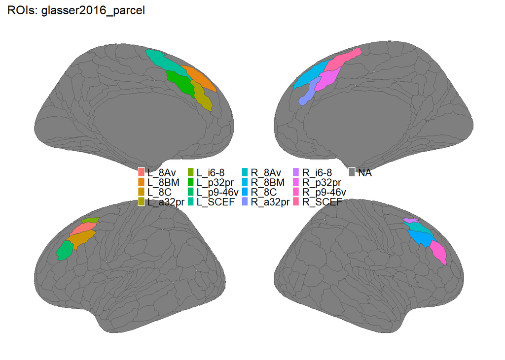

```r
atlas$data %>%
  ggplot() +
    geom_brain(
      aes(fill = ifelse(region %in% rois$region, region, NA)),
      atlas = atlas, position = position_brain(side ~ hemi)
      ) +
  labs(title = paste0("ROIs: ", roiset), fill = NULL) +
  theme_surface +
  theme(legend.text = element_text(size = 10))
```

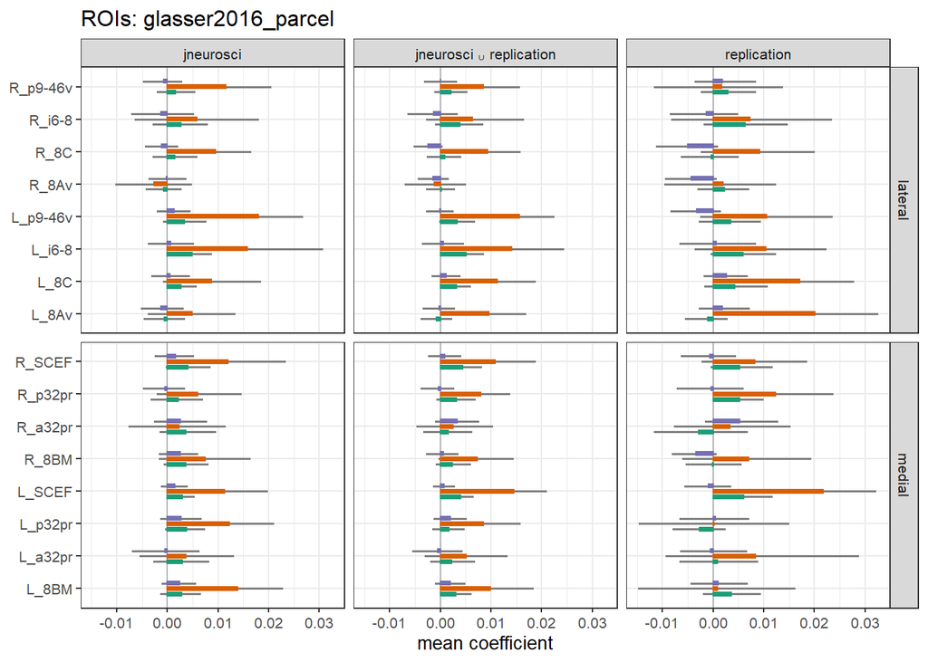

```r
dat_subjs_barplots %>%

  right_join(rois, by = "region") %>%

  ggplot(aes(region_nice, b, fill = term, color = term)) +
  geom_hline(yintercept = 0, color = "grey70") +
  stat_summary(
    fun.data = mean_cl_boot, geom = "errorbar", width = 0, size = 2/3, position = position_dodge(width = 0.5),
    color = "grey50"
    ) +
  stat_summary(fun = mean, geom = "col", width = 1/3, position = position_dodge(width = 0.5)) +

  scale_color_brewer(type = "qual", palette = 2) +
  scale_fill_brewer(type = "qual", palette = 2) +

  facet_grid(cols = vars(subjlist), rows = vars(location), scales = "free_y") +
  theme(
    #axis.text.x = element_text(angle = 90, hjust = 1, vjust = 0.5),
    legend.position = "none", axis.title.y = element_blank()
    ) +
    labs(y = "mean coefficient", title = paste0("ROIs: ", roiset)) +
  coord_flip()
```